# Practice 3 : Analysis of trade scores

Authors:

- Martín Hijar Jiménez
- Eduardo Salgado Díaz del Río

8 January 2022

Subject: Machine Learning - Master's Degree in Data Science

### 2nd Machine learning practice notebook, market research on franchises

Due to the subsequent study, we have decided to investigate a little in the franchises that we consider most important, with a definite intention, which would be the possibilities of carrying out a machine learning project. through the reviews of the previously selected franchises.

First, we define the functions that we are going to use in the notebook.

Secondly, we take out the different franchises we want to use.

To continue, we select the franchises we are interested in, in this case Dunkin, Starbucks, Burger King, Taco Bell and Mcdonalds.

Continuing with the introduction of the work done in this notebook, we made two dynamic graphs to continue with the visualisation of these and to provide more information about the market study we are carrying out.

Finally, we have decided to carry out a sentimental analysis that will be completed later with a neural network as a model of automatic learning, in this section we have subdivided it as follows:

- Global analysis of all the franchises as an example.
- Individual analysis of each franchise

Libraries

```python
import pandas as pd
import numpy as np
import json
import seaborn as sns
import matplotlib.pyplot as plt
import seaborn as sns
import plotly.express as px
import requests
from sklearn.impute import KNNImputer
import scipy.stats as ss
import warnings
import nltk
import collections
from nltk.corpus import stopwords
from nltk.sentiment.vader import SentimentIntensityAnalyzer
from plotly.offline import init_notebook_mode, iplot
import string
import regex as re
from wordcloud import WordCloud, STOPWORDS
```

[output not shown]

Define the functions

```python
def plot_wordcloud(df, column, title):
    df['text_clear'] = df[column].apply(preprocess)
    wc = WordCloud(width=1600, height=800, random_state=1, max_words=200000000)
    wc.generate(str(df['text_clear']))
    plt.figure(figsize=(10,5), facecolor='k')
    plt.title(title, fontsize=15,color='white')
    plt.imshow(wc, interpolation='bilinear')
    plt.axis('off')
    plt.tight_layout(pad=10)
    return plt.show()


# Defining some functions for later use for wordcloud
def preprocess(x):
    x = re.sub('[^a-z\s]', '', x.lower())                  # get rid of noise
    x = [w for w in x.split() if w not in set(stopwords)]  # remove stopwords
    return ' '.join(x) # then join the text again



def get_compound_score(text):
  scores = sia.polarity_scores(text)
  return scores['compound']

# For generating word pairs
import collections
from nltk.corpus import stopwords

# these are helper functions

def tokenize(s):
    """Convert string to lowercase and split into words (ignoring
    punctuation), returning list of words.
    """
    word_list = re.findall(r'\w+', s.lower())
    filtered_words = [word for word in word_list if word not in stopwords.words('english')]
    return filtered_words


def count_ngrams(lines, min_length=2, max_length=4):
    """Iterate through given lines iterator (file object or list of
    lines) and return n-gram frequencies. The return value is a dict
    mapping the length of the n-gram to a collections.Counter
    object of n-gram tuple and number of times that n-gram occurred.
    Returned dict includes n-grams of length min_length to max_length.
    """
    lengths = range(min_length, max_length + 1)
    ngrams = {length: collections.Counter() for length in lengths}
    queue = collections.deque(maxlen=max_length)

    # Helper function to add n-grams at start of current queue to dict
    def add_queue():
        current = tuple(queue)
        for length in lengths:
            if len(current) >= length:
                ngrams[length][current[:length]] += 1

    # Loop through all lines and words and add n-grams to dict
    for line in lines:
        for word in tokenize(line):
            queue.append(word)
            if len(queue) >= max_length:
                add_queue()

    # Make sure we get the n-grams at the tail end of the queue
    while len(queue) > min_length:
        queue.popleft()
        add_queue()

    return ngrams

def print_most_frequent(ngrams, num=10):
    """Print num most common n-grams of each length in n-grams dict."""
    for n in sorted(ngrams):
        print('----- {} most common {}-word phrase -----'.format(num, n))
        for gram, count in ngrams[n].most_common(num):
            print('{0}: {1}'.format(' '.join(gram), count))
        print('')
```

```python
# Read data

df_business = pd.read_parquet('../data/raw/business.parquet')
#df_checkin = pd.read_parquet('../data/raw/checkin.parquet')
df_review = pd.read_parquet('../data/raw/review.parquet')
#df_tip = pd.read_parquet('../data/raw/tip.parquet')
#df_user = pd.read_parquet('../data/raw/user.parquet')
```

```python
# Ratings,reviews and locations
company_rating=df_business.groupby(['name']).stars.mean()

company_review_count=df_business.groupby(['name']).review_count.sum()

company_city_count=df_business.groupby(['name']).city.nunique()

result = pd.concat([company_review_count, company_rating,company_city_count], axis=1, join='inner')
result.sort_values(by=['city'], ascending=False).head(10)
```

| name | review_count | stars | city |
| --- | --- | --- | --- |
| McDonald's | 17359 | 1.863442 | 263 |
| Dunkin' | 9864 | 2.302941 | 235 |
| Starbucks | 20692 | 3.126381 | 197 |
| Wawa | 4263 | 3.319218 | 167 |
| Domino's Pizza | 6291 | 2.281356 | 165 |
| Taco Bell | 8325 | 2.154795 | 164 |
| Burger King | 5255 | 2.028107 | 157 |
| CVS Pharmacy | 4481 | 2.456522 | 157 |
| Subway | 4123 | 2.586057 | 148 |
| Wendy's | 6164 | 2.015106 | 148 |

```python
# Selecting mcdonalds for review analysis
mcdonalds=df_business.loc[df_business['name'] == "McDonald's"]
mcdonalds[['name','business_id','review_count','stars']].sort_values(['review_count','stars'], ascending=[False,False]).head()
```

|  | name | business_id | review_count | stars |
| --- | --- | --- | --- | --- |
| 145369 | McDonald's | 3UHXD8T80OUFMCzLb3x-sQ | 176 | 1.0 |
| 147573 | McDonald's | RL6BaK196Scg2DEY3Uc1AQ | 160 | 1.5 |
| 146417 | McDonald's | a5TaDLChZDSgZ-en1sxNpw | 121 | 1.5 |
| 45077 | McDonald's | lA5BOb5Om5cn_dfwiOgbNg | 111 | 1.5 |
| 86328 | McDonald's | _mGAcxIOqKcL3muEg3LHLA | 106 | 1.5 |

```python
# Selecting Dunkin' for review analysis
Dunkin=df_business.loc[df_business['name'] == "Dunkin'"]
```

```python
#For starbucks
Starbucks=df_business.loc[df_business['name'] == "Starbucks"]
```

```python
#For Taco Bell
Taco_Bell=df_business.loc[df_business['name'] == "Taco Bell"]
```

```python
#For Burger King
Burger_King=df_business.loc[df_business['name'] == "Burger King"]
```

```python
# We create a new dataframe with the franchises that interest us
businesses=df_business[(df_business['name']=="McDonald's") |
                (df_business['name']=="Starbucks") |
               (df_business['name']=="Taco Bell") |
               (df_business['name']=="Burger King") |
               (df_business['name']=="Dunkin'")]
```

```python
# Drop duplicates
biz_ids=businesses.business_id.unique()
```

```python
# This code creates a new dataframe called yelp_review_bad which is a subset of the original df_review dataframe.
yelp_review=df_review.loc[df_review['business_id'].isin(biz_ids)]
```

```python
# We join both tables via Business_id
new_dataset=pd.merge(businesses,yelp_review,on='business_id')
```

```python
#stars classification of reviews on selected companies
grouped_df = new_dataset.groupby(by=["name", "stars_y"]).size().reset_index(name="counts")
grouped_df['percentage'] = 100 * grouped_df['counts'] / grouped_df.groupby('name')['counts'].transform('sum')



plot_3=px.bar(grouped_df,
       x='name',
       y=['counts'],
       color='stars_y',
       text=grouped_df['percentage'].apply(lambda x: '{0:1.2f}%'.format(x)),
      labels={
                     "name": "Companies",
                     "value": "Reviews Distribution",
                     "stars_y":"Legend"
                 },
                title="Distribution of Reviews Among Companies")

iplot(plot_3, filename='plot_3')
```

[output not shown]

In this graph we are performing which is the distribution of the reviews that are being given to the five franchises previously selected grouping them by the stars received, this graph is a dynamic graph specifying when you click on it, it gives you the following information:

- Company
- Review distribution (Total number of reviews with those stars)
- Legend (Rating in the form of stars rated by the customer)

```python
# To show that yelp review count is decreasing overtime
new_dataset['year'] = pd.DatetimeIndex(new_dataset['date']).year
time_series=new_dataset.groupby(by=["name", "year"]).size().reset_index(name="counts")

plot_4 = px.bar(time_series, x="year", y="counts",
             color="name",
             barmode = 'group',
            labels={
                     "year": "Year",
                     "counts": "Count of Reviews",
                     "name": "Companies"
                 },
                title="Distribution of Reviews overtime for selected  companies")

iplot(plot_4, filename='plot_4')
```

[interactive chart not shown]

Dynamic graph that counts the number of reviews received by each selected company over the years, counting the reviews on an annual basis

# Sentiment analysis

Sentiment analysis of the different people who have been customers of the franchises selected above.

Brief analysis of their reviews

Most used words in franchise reviews

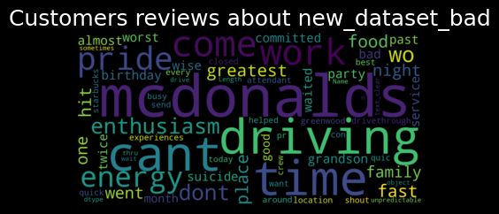

```python
sia = SentimentIntensityAnalyzer()


# let's find out which stopwords need to remove. We'll use english stopwords.
i = nltk.corpus.stopwords.words('english')
# punctuations to remove
j = list(string.punctuation)
# finally let's combine all of these
stopwords = set(i).union(j)

# clear the text
new_dataset['text_clear'] = new_dataset['text'].apply(preprocess)

wc = WordCloud(width=1600, height=800, random_state=1, max_words=200000000)
# generate word cloud
wc.generate(str(new_dataset['text_clear']))
plt.figure(figsize=(10,5), facecolor='k')
# add title to the graph
plt.title("Customers reviews about new_dataset_bad", fontsize=18,color='white')
plt.imshow(wc, interpolation='bilinear')
plt.axis('off')
plt.tight_layout(pad=10)
# after lot of configuration finally plot the graph
plt.show()
```

```python
new_dataset['compound'] = new_dataset['text_clear'].apply(get_compound_score)
```

## McDonald's

In this first analysis of the McDonald's franchise, we proceed to separate the dataset by filtering the franchise and continue with the same analysis as before.

```python
mcdonalds = new_dataset.loc[new_dataset['name'] == "McDonald's"]
```

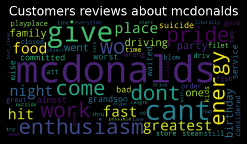

```python
i = nltk.corpus.stopwords.words('english')
# punctuations to remove
j = list(string.punctuation)
# finally let's combine all of these
stopwords = set(i).union(j)
# clear the text
mcdonalds['text_clear'] = mcdonalds['text'].apply(preprocess)

plot_wordcloud(mcdonalds, 'text', "Customers reviews about mcdonalds")
```

```python
mcdonalds['compound'] = mcdonalds['text_clear'].apply(get_compound_score)
```

```python
#spliting dataframe to into postive and negative based on the review nature
mcdonalds_positive = mcdonalds[mcdonalds['compound'] > 0]
mcdonalds_negative = mcdonalds[mcdonalds['compound'] <= 0]
```

In this step of the project, we made a code in order to get the two most used words of positive effect by having previously made a compound, this code is used to know which are the first 5 two words used in the review of McDonalds and then the same but with the three most used, this code runs the positive, then we will perform the same exercise but with the negative words.

```python
print("Most used positive words pairs of Mcdonalds")
most_used_text_mcdonalds_positive = mcdonalds_positive.text_clear.values
most_used_text_mcdonalds_positive = count_ngrams(most_used_text_mcdonalds_positive,max_length=3)
print_most_frequent(most_used_text_mcdonalds_positive, num=5)
```

```
Most used positive words pairs of Mcdonalds
----- 5 most common 2-word phrase -----
drive thru: 1517
fast food: 969
customer service: 705
ice cream: 352
every time: 325

----- 5 most common 3-word phrase -----
ice cream machine: 103
fast food restaurant: 94
mcdonalds ive ever: 83
went drive thru: 79
drive thru line: 77
```

```python
print_most_used_ngrams(mcdonalds_negative, 'text_clear', 3, 5)
```

[output not shown]

### Burger King

```python
i = nltk.corpus.stopwords.words('english')
# punctuations to remove
j = list(string.punctuation)
# finally let's combine all of these
stopwords = set(i).union(j)
Burger_King = new_dataset.loc[new_dataset['name'] == "Burger King"]
Burger_King['text_clear'] = Burger_King['text'].apply(preprocess)
```

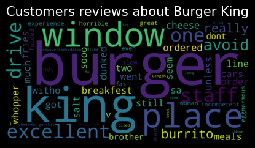

```python
plot_wordcloud(Burger_King, 'text', "Customers reviews about Burger King")
```

We plot the words most used by customers of the Burger King franchise in the reviews of the dataset.

```python
Burger_King['compound'] = Burger_King['text_clear'].apply(get_compound_score)
```

```python
Burger_King_positive = Burger_King[Burger_King['compound'] > 0]

Burger_King_negative = Burger_King[Burger_King['compound'] <= 0]
```

### Starbucks

```python
Starbucks = new_dataset.loc[new_dataset['name'] == "Starbucks"]
Starbucks['text_clear'] = Starbucks['text'].apply(preprocess)
```

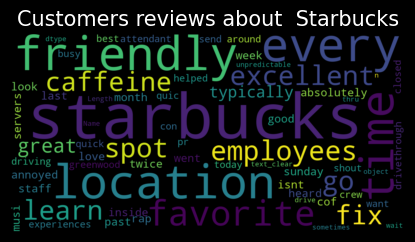

```python
plot_wordcloud(Starbucks, 'text', "Customers reviews about  Starbucks")
```

```python
Starbucks['compound'] = Starbucks['text_clear'].apply(get_compound_score)
```

### Dunkin

```python
Dunkin = new_dataset.loc[new_dataset['name'] == "Dunkin'"]
Dunkin['text_clear'] = Dunkin['text'].apply(preprocess)
```

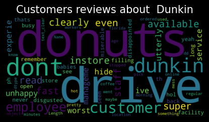

```python
plot_wordcloud(Dunkin, 'text', "Customers reviews about  Dunkin")
```

### Taco Bell

```python
Taco_Bell = new_dataset.loc[new_dataset['name'] == "Taco Bell"]
Taco_Bell['text_clear'] = Taco_Bell['text'].apply(preprocess)
```

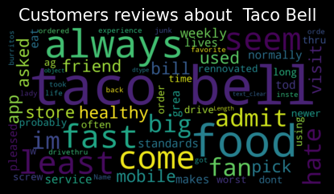

```python
plot_wordcloud(Taco_Bell, 'text', "Customers reviews about  Taco Bell")
```